# Analityk kredytowy w Dream Housing Finance Company

Martyna Szypuła, Katarzyna Wójcik

## Wyższa Szkoła Informatyki i Zarządzania z siedzibą w Rzeszowie

| Imię i Nazwisko: | Martyna Szypuła | Katarzyna Wójcik |
| --- | --- | --- |
| Numer albumu: | 69852 | 70855 |
| Rok, semestr, kierunek studiów: | 4 IIZ/2023/IZ |  |
| Rok akademicki: | 2024/2025 |  |
| Nazwa przedmiotu: | Drążenie danych |  |
| Prowadzący: | dr Sebastian Wójcik |  |

## Opis sytuacji

Dream Housing Finance Company oferuje wszelkiego rodzaju pożyczki i kredyty. Obecne są na wszystkich obszarach miejskich, pół miejskich i wiejskich. Klient najpierw aplikuje o pożyczkę bądź kredyt, a następnie analityk kredytowy podejmuje ostateczną decyzją o przyznaniu klientowi pożyczki. Firma chce zautomatyzować proces przyznawania pożyczek (w czasie rzeczywistym) na podstawie szczegółów klienta dostarczonych podczas wypełniania formularza aplikacyjnego online. Te szczegóły to płeć, stan cywilny, edukacja, liczba osób pozostających na utrzymaniu, dochód, kwota pożyczki, historia kredytowa i inne. Aby zautomatyzować ten proces, dostarczyli zestaw danych o dotychczasowych decyzjach przyznania i odrzucenia wniosku kredytowego dla ponad 600 klientów. Potrzebują, aby przeanalizować dane i przygotować raport jak poszczególne zmienne wpływają na decyzję kredytową.

## Biblioteki

```r
#Instalowanie
# options(repos = c(CRAN = "https://cloud.r-project.org"))
# install.packages(c("readr", "knitr", "kableExtra", "dplyr", "e1071", "ggplot2", "caret", "MLmetrics", "rpart"), dependencies = TRUE)

#Importowanie
library(readr)
library(knitr)
library(kableExtra)
library(dplyr)
library(e1071)
library(ggplot2)
library(tidyr)
library(caret)
library(MLmetrics)
library(rpart)
```

## Dane

Plik CSV zawierający dane o klientach z nadanym statusem przyznania bądź nie pożyczki ‘Loan_Status’

```r
loan_data <- tidyr::drop_na(read_delim("C:/Users/katar/Downloads/Loan predictions - Dream Housing Finance Company/Loan predictions - Dream Housing Finance Company/train.csv", delim = ";",
  escape_double = FALSE, col_types = cols(Dependents = col_number(),
  LoanAmount = col_double()), trim_ws = TRUE))
```

```r
loan_data %>%
  knitr::kable(col.names = gsub("[_]", " ", names(loan_data)), align = 'c', digits = 2, format.args = list(big.mark = ",")) %>%
  scroll_box(width = "100%", height = "300px") %>%
  kable_styling(bootstrap_options = c("striped", "responsive"), full_width = FALSE, position = "left", fixed_thead = TRUE)
```

| Loan ID | Gender | Married | Dependents | Education | Self Employed | ApplicantIncome | CoapplicantIncome | LoanAmount | Loan Amount Term | Credit HistorYes | Property Area | Loan Status |
| --- | --- | --- | --- | --- | --- | --- | --- | --- | --- | --- | --- | --- |
| LP001003 | Male | Yes | 1 | Graduate | No | 4,583 | 1,508.00 | 128 | 360 | Yes | Rural | No |
| LP001005 | Male | Yes | 0 | Graduate | Yes | 3,000 | 0.00 | 66 | 360 | Yes | Urban | Yes |
| LP001006 | Male | Yes | 0 | Not Graduate | No | 2,583 | 2,358.00 | 120 | 360 | Yes | Urban | Yes |
| LP001008 | Male | No | 0 | Graduate | No | 6,000 | 0.00 | 141 | 360 | Yes | Urban | Yes |
| LP001011 | Male | Yes | 2 | Graduate | Yes | 5,417 | 4,196.00 | 267 | 360 | Yes | Urban | Yes |
| LP001013 | Male | Yes | 0 | Not Graduate | No | 2,333 | 1,516.00 | 95 | 360 | Yes | Urban | Yes |
| LP001014 | Male | Yes | 3 | Graduate | No | 3,036 | 2,504.00 | 158 | 360 | No | Semiurban | No |
| LP001018 | Male | Yes | 2 | Graduate | No | 4,006 | 1,526.00 | 168 | 360 | Yes | Urban | Yes |
| LP001020 | Male | Yes | 1 | Graduate | No | 12,841 | 10,968.00 | 349 | 360 | Yes | Semiurban | No |
| LP001024 | Male | Yes | 2 | Graduate | No | 3,200 | 700.00 | 70 | 360 | Yes | Urban | Yes |
| LP001028 | Male | Yes | 2 | Graduate | No | 3,073 | 8,106.00 | 200 | 360 | Yes | Urban | Yes |
| LP001029 | Male | No | 0 | Graduate | No | 1,853 | 2,840.00 | 114 | 360 | Yes | Rural | No |
| LP001030 | Male | Yes | 2 | Graduate | No | 1,299 | 1,086.00 | 17 | 120 | Yes | Urban | Yes |
| LP001032 | Male | No | 0 | Graduate | No | 4,950 | 0.00 | 125 | 360 | Yes | Urban | Yes |
| LP001036 | Female | No | 0 | Graduate | No | 3,510 | 0.00 | 76 | 360 | No | Urban | No |
| LP001038 | Male | Yes | 0 | Not Graduate | No | 4,887 | 0.00 | 133 | 360 | Yes | Rural | No |
| LP001043 | Male | Yes | 0 | Not Graduate | No | 7,660 | 0.00 | 104 | 360 | No | Urban | No |
| LP001046 | Male | Yes | 1 | Graduate | No | 5,955 | 5,625.00 | 315 | 360 | Yes | Urban | Yes |
| LP001047 | Male | Yes | 0 | Not Graduate | No | 2,600 | 1,911.00 | 116 | 360 | No | Semiurban | No |
| LP001066 | Male | Yes | 0 | Graduate | Yes | 9,560 | 0.00 | 191 | 360 | Yes | Semiurban | Yes |
| LP001068 | Male | Yes | 0 | Graduate | No | 2,799 | 2,253.00 | 122 | 360 | Yes | Semiurban | Yes |
| LP001073 | Male | Yes | 2 | Not Graduate | No | 4,226 | 1,040.00 | 110 | 360 | Yes | Urban | Yes |
| LP001086 | Male | No | 0 | Not Graduate | No | 1,442 | 0.00 | 35 | 360 | Yes | Urban | No |
| LP001095 | Male | No | 0 | Graduate | No | 3,167 | 0.00 | 74 | 360 | Yes | Urban | No |
| LP001097 | Male | No | 1 | Graduate | Yes | 4,692 | 0.00 | 106 | 360 | Yes | Rural | No |
| LP001098 | Male | Yes | 0 | Graduate | No | 3,500 | 1,667.00 | 114 | 360 | Yes | Semiurban | Yes |
| LP001100 | Male | No | 3 | Graduate | No | 12,500 | 3,000.00 | 320 | 360 | Yes | Rural | No |
| LP001112 | Female | Yes | 0 | Graduate | No | 3,667 | 1,459.00 | 144 | 360 | Yes | Semiurban | Yes |
| LP001114 | Male | No | 0 | Graduate | No | 4,166 | 7,210.00 | 184 | 360 | Yes | Urban | Yes |
| LP001116 | Male | No | 0 | Not Graduate | No | 3,748 | 1,668.00 | 110 | 360 | Yes | Semiurban | Yes |

[output cut: 450 more lines]

### Zadanie 1

Scharakteryzuj zmienne ApplicantIncome, CoapplicantIncome, LoanAmount w zakresie: minimum, pierwszy kwartyl, medina, średnia, trzeci kwartyl, maksimum, odchylenie standardowe, wybrana miarę asymetrii i koncentracji w każdej z grup: według płci (Gender) i według stanu cywilnego (Married).

#### Według płci

```r
# ApplicantIncome
loan_data %>% dplyr::group_by(Gender) %>% dplyr::summarise(
  Minimum = min(ApplicantIncome, na.rm = TRUE),
  Q1 = quantile(ApplicantIncome, probs = 0.25, na.rm = TRUE),
  Mediana = median(ApplicantIncome, na.rm = TRUE),
  Srednia = mean(ApplicantIncome, na.rm = TRUE),
  Q3 = quantile(ApplicantIncome, probs = 0.75, na_rm = TRUE),
  Maksimum = max(ApplicantIncome, na.rm = TRUE),
  Odchylenie = sd(ApplicantIncome, na.rm = TRUE),
  Asymetria_TMC = e1071::skewness(ApplicantIncome, na.rm = TRUE), # Jawne wywołanie
  Kurtoza = e1071::kurtosis(ApplicantIncome, na.rm = TRUE)        # Jawne wywołanie
) %>%
  knitr::kable(caption = 'ApplicantIncome (według płci)', align = 'c', digits = 2, format.args = list(big.mark = ",")) %>%
  kable_styling(bootstrap_options = c("striped", "responsive"), full_width = FALSE, position = "left")
```

ApplicantIncome (według płci)

| Gender | Minimum | Q1 | Mediana | Srednia | Q3 | Maksimum | Odchylenie | Asymetria_TMC | Kurtoza |
| --- | --- | --- | --- | --- | --- | --- | --- | --- | --- |
| Female | 645 | 2,611.25 | 3,787 | 4,968.59 | 4,708.75 | 19,484 | 3,899.41 | 2.06 | 3.75 |
| Male | 150 | 2,929.00 | 3,881 | 5,450.59 | 5,988.75 | 81,000 | 5,985.77 | 6.96 | 70.78 |

```r
# CoapplicantIncome
loan_data %>% dplyr::group_by(Gender) %>% dplyr::summarise(
  Minimum = min(CoapplicantIncome, na.rm = TRUE),
  Q1 = quantile(CoapplicantIncome, probs = 0.25, na.rm = TRUE),
  Mediana = median(CoapplicantIncome, na.rm = TRUE),
  Srednia = mean(CoapplicantIncome, na.rm = TRUE),
  Q3 = quantile(CoapplicantIncome, probs = 0.75, na.rm = TRUE),
  Maksimum = max(CoapplicantIncome, na.rm = TRUE),
  Odchylenie = sd(CoapplicantIncome, na.rm = TRUE),
  Asymetria_TMC = e1071::skewness(CoapplicantIncome, na.rm = TRUE),
  Kurtoza = e1071::kurtosis(CoapplicantIncome, na.rm = TRUE)
) %>%
  knitr::kable(caption = 'CoapplicantIncome (według płci)', align = 'c', digits = 2, format.args = list(big.mark = ",")) %>%
  kable_styling(bootstrap_options = c("striped", "responsive"), full_width = FALSE, position = "left")
```

CoapplicantIncome (według płci)

| Gender | Minimum | Q1 | Mediana | Srednia | Q3 | Maksimum | Odchylenie | Asymetria_TMC | Kurtoza |
| --- | --- | --- | --- | --- | --- | --- | --- | --- | --- |
| Female | 0 | 0 | 0.0 | 706.99 | 1,534.75 | 8,980 | 1,404.86 | 2.98 | 12.39 |
| Male | 0 | 0 | 1,427.5 | 1,771.89 | 2,416.75 | 33,837 | 2,778.71 | 5.72 | 52.63 |

```r
# LoanAmount
loan_data %>% dplyr::group_by(Gender) %>% dplyr::summarise(
  Minimum = min(LoanAmount, na.rm = TRUE),
  Q1 = quantile(LoanAmount, probs = 0.25, na.rm = TRUE),
  Mediana = median(LoanAmount, na.rm = TRUE),
  Srednia = mean(LoanAmount, na.rm = TRUE),
  Q3 = quantile(LoanAmount, probs = 0.75, na.rm = TRUE),
  Maksimum = max(LoanAmount, na.rm = TRUE),
  Odchylenie = sd(LoanAmount, na.rm = TRUE),
  Asymetria_TMC = e1071::skewness(LoanAmount, na.rm = TRUE),
  Kurtoza = e1071::kurtosis(LoanAmount, na.rm = TRUE)
) %>%
  knitr::kable(caption = 'LoanAmount (według płci)', align = 'c', digits = 2, format.args = list(big.mark = ",")) %>%
  kable_styling(bootstrap_options = c("striped", "responsive"), full_width = FALSE, position = "left")
```

LoanAmount (według płci)

| Gender | Minimum | Q1 | Mediana | Srednia | Q3 | Maksimum | Odchylenie | Asymetria_TMC | Kurtoza |
| --- | --- | --- | --- | --- | --- | --- | --- | --- | --- |
| Female | 9 | 81 | 112.5 | 127.70 | 143 | 600 | 85.22 | 3.02 | 12.64 |
| Male | 17 | 104 | 130.0 | 148.45 | 175 | 600 | 79.07 | 2.22 | 7.47 |

#### Według stanu cywilnego

```r
# Wcześniej był filter(is.na(Married) == FALSE) - po imputacji nie ma potrzeby
# ApplicantIncome
loan_data %>% dplyr::group_by(Married) %>% dplyr::summarise(
  Minimum = min(ApplicantIncome, na.rm = TRUE),
  Q1 = quantile(ApplicantIncome, probs = 0.25, na.rm = TRUE),
  Mediana = median(ApplicantIncome, na.rm = TRUE),
  Srednia = mean(ApplicantIncome, na.rm = TRUE),
  Q3 = quantile(ApplicantIncome, probs = 0.75, na.rm = TRUE),
  Maksimum = max(ApplicantIncome, na.rm = TRUE),
  Odchylenie = sd(ApplicantIncome, na.rm = TRUE),
  Asymetria_TMC = e1071::skewness(ApplicantIncome, na.rm = TRUE),
  Kurtoza = e1071::kurtosis(ApplicantIncome, na.rm = TRUE)
) %>%
  knitr::kable(caption = 'ApplicantIncome (według stanu cywilnego)', align = 'c', digits = 2, format.args = list(big.mark = ",")) %>%
  kable_styling(bootstrap_options = c("striped", "responsive"), full_width = FALSE, position = "left")
```

ApplicantIncome (według stanu cywilnego)

| Married | Minimum | Q1 | Mediana | Srednia | Q3 | Maksimum | Odchylenie | Asymetria_TMC | Kurtoza |
| --- | --- | --- | --- | --- | --- | --- | --- | --- | --- |
| No | 645 | 2,935.0 | 3,858 | 5,082.20 | 5,800 | 37,719 | 4,147.16 | 3.92 | 22.92 |
| Yes | 150 | 2,840.5 | 3,859 | 5,517.49 | 5,929 | 81,000 | 6,344.84 | 6.93 | 68.54 |

```r
# CoapplicantIncome
loan_data %>% dplyr::group_by(Married) %>% dplyr::summarise(
  Minimum = min(CoapplicantIncome, na.rm = TRUE),
  Q1 = quantile(CoapplicantIncome, probs = 0.25, na.rm = TRUE),
  Mediana = median(CoapplicantIncome, na.rm = TRUE),
  Srednia = mean(CoapplicantIncome, na.rm = TRUE),
  Q3 = quantile(CoapplicantIncome, probs = 0.75, na.rm = TRUE),
  Maksimum = max(CoapplicantIncome, na.rm = TRUE),
  Odchylenie = sd(CoapplicantIncome, na.rm = TRUE),
  Asymetria_TMC = e1071::skewness(CoapplicantIncome, na.rm = TRUE),
  Kurtoza = e1071::kurtosis(CoapplicantIncome, na.rm = TRUE)
) %>%
  knitr::kable(caption = 'CoapplicantIncome (według stanu cywilnego)', align = 'c', digits = 2, format.args = list(big.mark = ",")) %>%
  kable_styling(bootstrap_options = c("striped", "responsive"), full_width = FALSE, position = "left")
```

CoapplicantIncome (według stanu cywilnego)

| Married | Minimum | Q1 | Mediana | Srednia | Q3 | Maksimum | Odchylenie | Asymetria_TMC | Kurtoza |
| --- | --- | --- | --- | --- | --- | --- | --- | --- | --- |
| No | 0 | 0 | 0 | 1,215.89 | 1,783.0 | 33,837 | 3,320.44 | 6.84 | 58.51 |
| Yes | 0 | 0 | 1,587 | 1,779.55 | 2,426.5 | 20,000 | 2,121.49 | 3.10 | 18.70 |

```r
# LoanAmount
loan_data %>% dplyr::group_by(Married) %>% dplyr::summarise(
  Minimum = min(LoanAmount, na.rm = TRUE),
  Q1 = quantile(LoanAmount, probs = 0.25, na.rm = TRUE),
  Mediana = median(LoanAmount, na.rm = TRUE),
  Srednia = mean(LoanAmount, na.rm = TRUE),
  Q3 = quantile(LoanAmount, probs = 0.75, na.rm = TRUE),
  Maksimum = max(LoanAmount, na.rm = TRUE),
  Odchylenie = sd(LoanAmount, na.rm = TRUE),
  Asymetria_TMC = e1071::skewness(LoanAmount, na.rm = TRUE),
  Kurtoza = e1071::kurtosis(LoanAmount, na.rm = TRUE)
) %>%
  knitr::kable(caption = 'LoanAmount (według stanu cywilnego)', align = 'c', digits = 2, format.args = list(big.mark = ",")) %>%
  kable_styling(bootstrap_options = c("striped", "responsive"), full_width = FALSE, position = "left")
```

LoanAmount (według stanu cywilnego)

| Married | Minimum | Q1 | Mediana | Srednia | Q3 | Maksimum | Odchylenie | Asymetria_TMC | Kurtoza |
| --- | --- | --- | --- | --- | --- | --- | --- | --- | --- |
| No | 9 | 81 | 115 | 124.72 | 150 | 480 | 63.34 | 1.74 | 5.76 |
| Yes | 17 | 108 | 133 | 155.61 | 180 | 600 | 86.62 | 2.37 | 7.68 |

### Zadanie 2

Oblicz jak często pożyczkę dostawały osoby Married=Y a jak często osoby Married=N. (tabela liczności).

```r
cat("### Częstość przyznawania pożyczek według stanu cywilnego (Married) ###\n")
```

```
## ### Częstość przyznawania pożyczek według stanu cywilnego (Married) ###
```

```r
loan_status_married_df <- loan_data %>%
  dplyr::group_by(Married, Loan_Status) %>%
  dplyr::summarise(Liczba = n(), .groups = 'drop') %>% # Dodano .groups = 'drop' dla czystszego wyniku
  dplyr::ungroup() %>%
  dplyr::group_by(Married) %>%
  dplyr::mutate(Procent = Liczba / sum(Liczba) * 100)

loan_status_married_df %>%
  knitr::kable(
    caption = 'Częstość przyznawania pożyczek według stanu cywilnego',
    align = 'c',
    digits = 2,
    format.args = list(big.mark = ",") # Formatowanie liczb
  ) %>%
  kable_styling(
    bootstrap_options = c("striped", "responsive"),
    full_width = FALSE,
    position = "left"
  )
```

Częstość przyznawania pożyczek według stanu cywilnego

| Married | Loan_Status | Liczba | Procent |
| --- | --- | --- | --- |
| No | No | 64 | 37.87 |
| No | Yes | 105 | 62.13 |
| Yes | No | 84 | 27.01 |
| Yes | Yes | 227 | 72.99 |

### Zadanie 3

Oblicz jak często pożyczkę dostawały osoby Self_employed=Y a jak często osoby Self_employed=N. (tabela liczności).

```r
loan_status_self_employed <- loan_data %>%
  dplyr::group_by(Self_Employed, Loan_Status) %>%
  dplyr::summarise(Liczba = n()) %>% # Dodano .groups = 'drop' dla czystszego wyniku
  dplyr::ungroup() %>%
  dplyr::group_by(Self_Employed) %>%
  dplyr::mutate(Procent = Liczba / sum(Liczba) * 100)

loan_status_self_employed %>%
  knitr::kable(
    caption = 'Częstość przyznawania pożyczek według statusu zatrudnienia',
    align = 'c',
    digits = 2,
    format.args = list(big.mark = ",") # Formatowanie liczb
  ) %>%
  kable_styling(
    bootstrap_options = c("striped", "responsive"),
    full_width = FALSE,
    position = "left"
  )
```

Częstość przyznawania pożyczek według statusu zatrudnienia

| Self_Employed | Loan_Status | Liczba | Procent |
| --- | --- | --- | --- |
| No | No | 125 | 30.19 |
| No | Yes | 289 | 69.81 |
| Yes | No | 23 | 34.85 |
| Yes | Yes | 43 | 65.15 |

```r
loan_status_self_employed
```

```
## # A tibble: 4 × 4
## # Groups:   Self_Employed [2]
##   Self_Employed Loan_Status Liczba Procent
##   <chr>         <chr>        <int>   <dbl>
## 1 No            No             125    30.2
## 2 No            Yes            289    69.8
## 3 Yes           No              23    34.8
## 4 Yes           Yes             43    65.2
```

### Zadanie 4

Dla wybranych zmiennych zrób wykres ramka-wąsy (boxplot). Niech zmienna Gender będzie tworzyła serie. Dodał tytuł, opis osi, legendę.

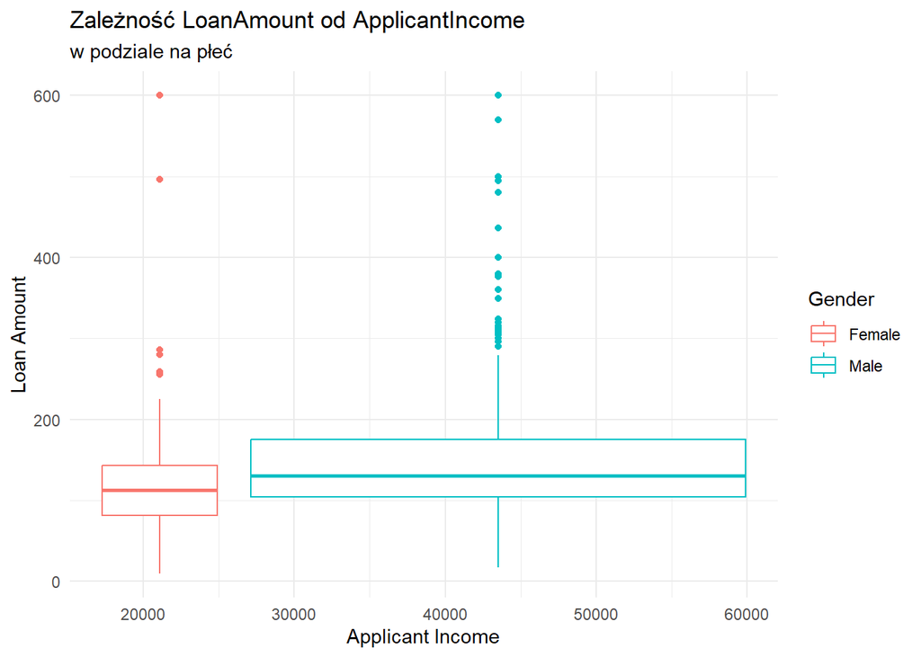

```r
ggplot(data = loan_data,
       mapping = aes(x = ApplicantIncome, y = LoanAmount, color = Gender),
       na_rm = TRUE
       ) +
  geom_boxplot(mapping = aes(color = Gender)) +
  labs(
    title = "Zależność LoanAmount od ApplicantIncome",
    subtitle = "w podziale na płeć",
    x = "Applicant Income",
    y = "Loan Amount",
    color = "Gender"
  ) +
  theme_minimal()
```

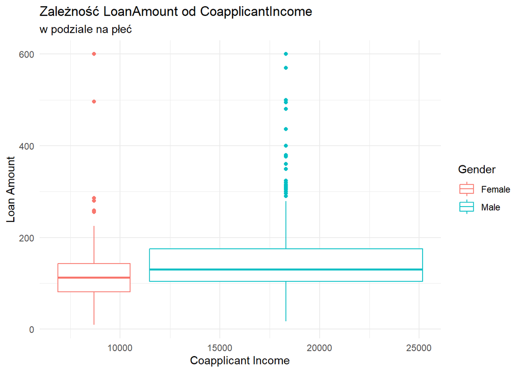

```r
ggplot(data = loan_data,
       mapping = aes(x = CoapplicantIncome, y = LoanAmount, color = Gender),
       na_rm = TRUE
       ) +
  geom_boxplot(mapping = aes(color = Gender)) +
  labs(
    title = "Zależność LoanAmount od CoapplicantIncome",
    subtitle = "w podziale na płeć",
    x = "Coapplicant Income",
    y = "Loan Amount",
    color = "Gender"
  ) +
  theme_minimal()
```

### Zadanie 5

Dla wybranych zmiennych zrób wykres ramka-wąsy (boxplot). Niech zmienna Married będzie tworzyła serie. Dodał tytuł, opis osi, legendę.

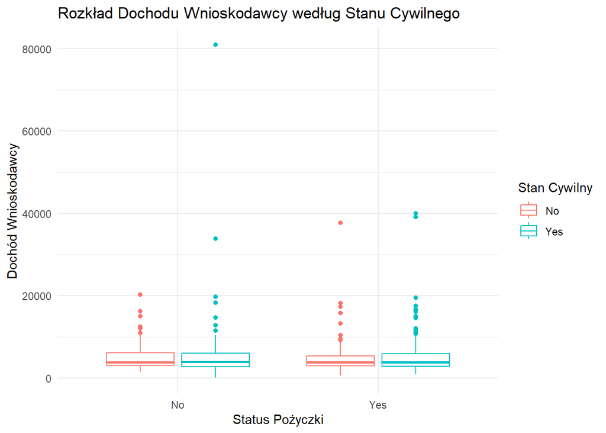

```r
ggplot(data = loan_data,
       aes(x = Loan_Status, y = ApplicantIncome, color = Married)) +
  geom_boxplot(aes(color = Married)) +
  labs(title = "Rozkład Dochodu Wnioskodawcy według Stanu Cywilnego",
       x = "Status Pożyczki",
       y = "Dochód Wnioskodawcy",
       color = "Stan Cywilny") +
  theme_minimal()
```

### Zadanie 6

Dla pary zmiennych ApplicantIncome, CoapplicantIncome zrób wykres rozrzutu. Niech zmienna Self_employed będzie tworzyła serie. Dodał tytuł, opis osi, legendę.

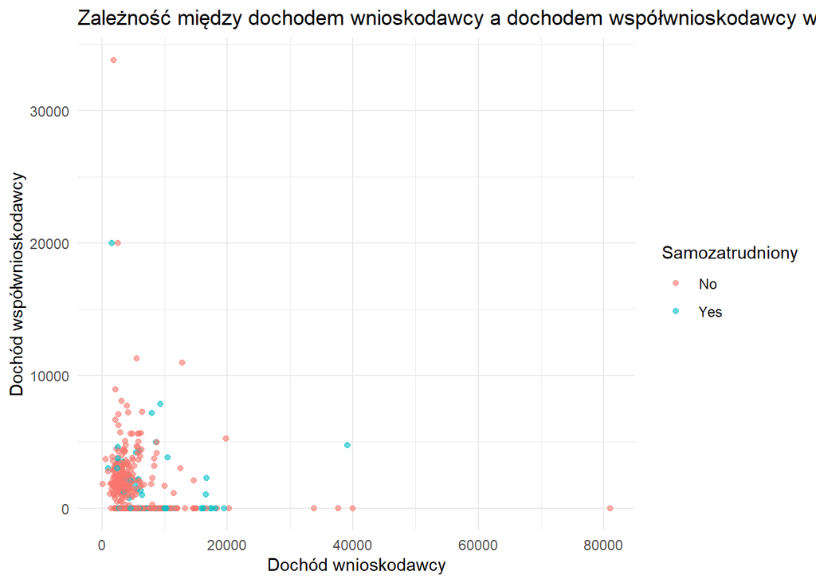

```r
  ggplot(data = loan_data, aes(x = ApplicantIncome, y = CoapplicantIncome, color = Self_Employed)) +
  geom_point(alpha = 0.6) +
  labs(
    title = "Zależność między dochodem wnioskodawcy a dochodem współwnioskodawcy według statusu zatrudnienia",
    x = "Dochód wnioskodawcy",
    y = "Dochód współwnioskodawcy",
    color = "Samozatrudniony"
  ) +
  theme_minimal()
```

### Zadanie 7

Dla pary zmiennych ApplicantIncome, CoapplicantIncome zrób wykres rozrzutu. Niech zmienna Self_employed będzie tworzyła serie. Dodał tytuł, opis osi, legendę.

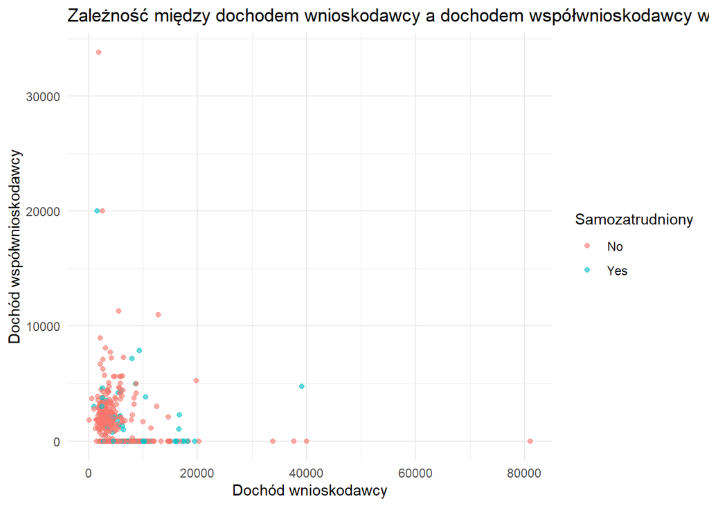

```r
  ggplot(data = loan_data, aes(x = ApplicantIncome, y = CoapplicantIncome, color = Self_Employed)) +
  geom_point(alpha = 0.6) +
  labs(
    title = "Zależność między dochodem wnioskodawcy a dochodem współwnioskodawcy według statusu zatrudnienia",
    x = "Dochód wnioskodawcy",
    y = "Dochód współwnioskodawcy",
    color = "Samozatrudniony"
  ) +
  theme_minimal()
```

### Zadanie 8

Dla par zmiennych ApplicantIncome, LoanAmount zrób wykres rozrzutu. Niech zmienna Married będzie tworzyła serie. Dodał tytuł, opis osi, legendę.

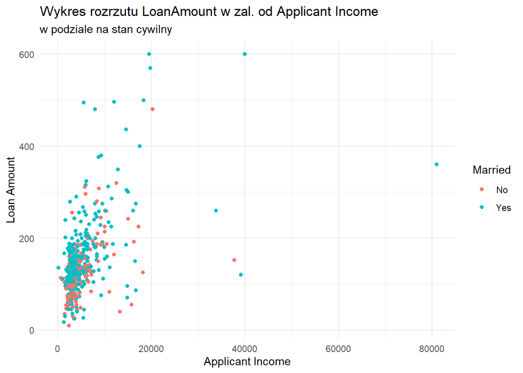

```r
ggplot(data = (loan_data %>% filter(is.na(Married) == FALSE)),
       mapping = aes(x = ApplicantIncome, y = LoanAmount, color = Married),
       na_rm = TRUE
       ) +
  geom_point(mapping = aes(color = Married)) +
  labs(
    title = "Wykres rozrzutu LoanAmount w zal. od Applicant Income",
    subtitle = "w podziale na stan cywilny",
    x = "Applicant Income",
    y = "Loan Amount",
    color = "Married"
  ) +
  theme_minimal()
```

### Zadanie 9

#### Budowa 95% przedziałów ufności dla średniej i wariancji

Zbuduj 95% przedział ufności dla średniej i wariancji dla zmiennych ApplicantIncome, LoanAmount osobno dla kobiet i mężczyzn.

```r
# Inicjalizacja pustej ramki danych do przechowywania wyników
confidence_intervals_df <- data.frame(
  Zmienna = character(),
  Grupa = character(),
  Typ_Przedzialu = character(),
  Dolna_Granica = numeric(),
  Gorna_Granica = numeric(),
  stringsAsFactors = FALSE
)

# Funkcja pomocnicza do dodawania wierszy do ramki danych
add_interval_row <- function(df, variable, group, interval_type, lower, upper) {
  rbind(df, data.frame(
    Zmienna = variable,
    Grupa = group,
    Typ_Przedzialu = interval_type,
    Dolna_Granica = lower,
    Gorna_Granica = upper,
    stringsAsFactors = FALSE
  ))
}

alpha <- 0.05

# --- Dla ApplicantIncome ---
# Kobiety
income_female <- loan_data$ApplicantIncome[loan_data$Gender == "Female"]
cat(sprintf("\nApplicantIncome - Kobiety: Liczba obserwacji = %d\n", length(income_female)))
```

```
##
## ApplicantIncome - Kobiety: Liczba obserwacji = 86
```

```r
if (length(income_female) >= 2) {
  t_test_female_income <- t.test(income_female, conf.level = 0.95)
  confidence_intervals_df <- add_interval_row(confidence_intervals_df,
                                              "ApplicantIncome", "Kobiety", "Średnia",
                                              t_test_female_income$conf.int[1], t_test_female_income$conf.int[2])

  chi_sq_var_female_income <- var(income_female, na.rm = TRUE)
  n_female_income <- length(na.omit(income_female))
  lower_var_female_income <- ((n_female_income - 1) * chi_sq_var_female_income) / qchisq(1 - alpha/2, df = n_female_income - 1)
  upper_var_female_income <- ((n_female_income - 1) * chi_sq_var_female_income) / qchisq(alpha/2, df = n_female_income - 1)
  confidence_intervals_df <- add_interval_row(confidence_intervals_df,
                                              "ApplicantIncome", "Kobiety", "Wariancja",
                                              lower_var_female_income, upper_var_female_income)
} else {
  cat("Brak wystarczającej liczby obserwacji dla ApplicantIncome - Kobiet do obliczenia przedziałów ufności.\n")
}

# Mężczyźni
income_male <- loan_data$ApplicantIncome[loan_data$Gender == "Male"]
cat(sprintf("ApplicantIncome - Mężczyźni: Liczba obserwacji = %d\n", length(income_male)))
```

```
## ApplicantIncome - Mężczyźni: Liczba obserwacji = 394
```

```r
if (length(income_male) >= 2) {
  t_test_male_income <- t.test(income_male, conf.level = 0.95)
  confidence_intervals_df <- add_interval_row(confidence_intervals_df,
                                              "ApplicantIncome", "Mężczyźni", "Średnia",
                                              t_test_male_income$conf.int[1], t_test_male_income$conf.int[2])

  chi_sq_var_male_income <- var(income_male, na.rm = TRUE)
  n_male_income <- length(na.omit(income_male))
  lower_var_male_income <- ((n_male_income - 1) * chi_sq_var_male_income) / qchisq(1 - alpha/2, df = n_male_income - 1)
  upper_var_male_income <- ((n_male_income - 1) * chi_sq_var_male_income) / qchisq(alpha/2, df = n_male_income - 1)
  confidence_intervals_df <- add_interval_row(confidence_intervals_df,
                                              "ApplicantIncome", "Mężczyźni", "Wariancja",
                                              lower_var_male_income, upper_var_male_income)
} else {
  cat("Brak wystarczającej liczby obserwacji dla ApplicantIncome - Mężczyzn do obliczenia przedziałów ufności.\n")
}

# --- Dla LoanAmount ---
# Kobiety
loanamount_female <- loan_data$LoanAmount[loan_data$Gender == "Female"]
cat(sprintf("\nLoanAmount - Kobiety: Liczba obserwacji = %d\n", length(loanamount_female)))
```

```
##
## LoanAmount - Kobiety: Liczba obserwacji = 86
```

```r
if (length(loanamount_female) >= 2) {
  t_test_female_loanamount <- t.test(loanamount_female, conf.level = 0.95)
  confidence_intervals_df <- add_interval_row(confidence_intervals_df,
                                              "LoanAmount", "Kobiety", "Średnia",
                                              t_test_female_loanamount$conf.int[1], t_test_female_loanamount$conf.int[2])

  chi_sq_var_female_loanamount <- var(loanamount_female, na.rm = TRUE)
  n_female_loanamount <- length(na.omit(loanamount_female))
  lower_var_female_loanamount <- ((n_female_loanamount - 1) * chi_sq_var_female_loanamount) / qchisq(1 - alpha/2, df = n_female_loanamount - 1)
  upper_var_female_loanamount <- ((n_female_loanamount - 1) * chi_sq_var_female_loanamount) / qchisq(alpha/2, df = n_female_loanamount - 1)
  confidence_intervals_df <- add_interval_row(confidence_intervals_df,
                                              "LoanAmount", "Kobiety", "Wariancja",
                                              lower_var_female_loanamount, upper_var_female_loanamount)
} else {
  cat("Brak wystarczającej liczby obserwacji dla LoanAmount - Kobiet do obliczenia przedziałów ufności.\n")
}

# Mężczyźni
loanamount_male <- loan_data$LoanAmount[loan_data$Gender == "Male"]
cat(sprintf("LoanAmount - Mężczyźni: Liczba obserwacji = %d\n", length(loanamount_male)))
```

```
## LoanAmount - Mężczyźni: Liczba obserwacji = 394
```

```r
if (length(loanamount_male) >= 2) {
  t_test_male_loanamount <- t.test(loanamount_male, conf.level = 0.95)
  confidence_intervals_df <- add_interval_row(confidence_intervals_df,
                                              "LoanAmount", "Mężczyźni", "Średnia",
                                              t_test_male_loanamount$conf.int[1], t_test_male_loanamount$conf.int[2])

  chi_sq_var_male_loanamount <- var(loanamount_male, na.rm = TRUE)
  n_male_loanamount <- length(na.omit(loanamount_male))
  lower_var_male_loanamount <- ((n_male_loanamount - 1) * chi_sq_var_male_loanamount) / qchisq(1 - alpha/2, df = n_male_loanamount - 1)
  upper_var_male_loanamount <- ((n_male_loanamount - 1) * chi_sq_var_male_loanamount) / qchisq(alpha/2, df = n_male_loanamount - 1)
  confidence_intervals_df <- add_interval_row(confidence_intervals_df,
                                              "LoanAmount", "Mężczyźni", "Wariancja",
                                              lower_var_male_loanamount, upper_var_male_loanamount)
} else {
  cat("Brak wystarczającej liczby obserwacji dla LoanAmount - Mężczyzn do obliczenia przedziałów ufności.\n")
}


# Wyświetlenie tabeli wyników
if (nrow(confidence_intervals_df) > 0) {
  confidence_intervals_df %>%
    knitr::kable(
      caption = '95% Przedziały Ufności dla średniej i wariancji (według płci)',
      align = 'c',
      digits = 2,
      format.args = list(big.mark = ",")
    ) %>%
    kable_styling(
      bootstrap_options = c("striped", "responsive"),
      full_width = FALSE,
      position = "left"
    )
} else {
  cat("\nBrak wystarczającej liczby danych do wygenerowania tabeli przedziałów ufności po usunięciu brakujących wartości.\n")
}
```

95% Przedziały Ufności dla średniej i wariancji (według płci)

| Zmienna | Grupa | Typ_Przedzialu | Dolna_Granica | Gorna_Granica |
| --- | --- | --- | --- | --- |
| ApplicantIncome | Kobiety | Średnia | 4,132.56 | 5,804.63 |
| ApplicantIncome | Kobiety | Wariancja | 11,499,425.57 | 21,053,673.80 |
| ApplicantIncome | Mężczyźni | Średnia | 4,857.72 | 6,043.46 |
| ApplicantIncome | Mężczyźni | Wariancja | 31,303,694.00 | 41,418,362.41 |
| LoanAmount | Kobiety | Średnia | 109.43 | 145.97 |
| LoanAmount | Kobiety | Wariancja | 5,492.37 | 10,055.68 |
| LoanAmount | Mężczyźni | Średnia | 140.62 | 156.29 |
| LoanAmount | Mężczyźni | Wariancja | 5,462.10 | 7,226.98 |

### Zadanie 10

Sprawdź czy średni poziom zmiennej ApplicantIncome różni się pomiędzy grupą osób, które otrzymały pożyczkę i nie (zmienna Loan_status)

```r
loan_data %>% group_by(Loan_Status) %>%
  summarise(Średnia = mean(ApplicantIncome, na.rm = TRUE)) %>%
  knitr::kable(caption = "Średnia ApplicantIncome", align = 'c', digits = 2, format.args = list(big.mark = ",")) %>%
  kable_styling(bootstrap_options = c("striped", "responsive"), full_width = FALSE, position = "left")
```

Średnia ApplicantIncome

| Loan_Status | Średnia |
| --- | --- |
| No | 5,730.19 |
| Yes | 5,201.09 |

### Zadanie 11

Sprawdź czy wariancja zmiennej ApplicantIncome różni się pomiędzy grupą osób, które otrzymały pożyczkę i nie (zmienna Loan_status)

```r
loan_data %>% group_by(Loan_Status) %>%
  summarise(Wariancja = var(ApplicantIncome, na.rm = TRUE)) %>%
  knitr::kable(caption = "Wariancja ApplicantIncome", align = 'c', digits = 2, format.args = list(big.mark = ",")) %>%
  kable_styling(bootstrap_options = c("striped", "responsive"), full_width = FALSE, position = "left")
```

Wariancja ApplicantIncome

| Loan_Status | Wariancja |
| --- | --- |
| No | 57,165,799 |
| Yes | 21,020,533 |

### Zdanie 12 Model

```r
library(dplyr)
#NA nie istnieją - usunięte przy ładowaniu danych

#Faktoryzacja zmiennych kategorycznych

Loan_Status <- as.factor(loan_data$Loan_Status)

# Pozostałe zmienne kategoryczne
categorical_cols <- c(
  "Gender", "Married", "Education", "Self_Employed", "Property_Area", "Credit_History", "Loan_Amount_Term")

for (col in categorical_cols) {
  if (col %in% names(loan_data)) {
    loan_data[[col]] <- as.factor(loan_data[[col]])
  }
}
loan_data <- loan_data[!names(loan_data) %in% "Loan_ID"]
# Podział danych na zbiór treningowy i testowy.
set.seed(123)
trainIndex <- caret::createDataPartition(Loan_Status, p = .8, list = FALSE)
data_train <- loan_data[ trainIndex,]
data_test  <- loan_data[-trainIndex,]

data_train["Loan_Status"] = factor(data_train$Loan_Status)
data_test["Loan_Status"] = factor(data_test$Loan_Status)

# Walidacja krzyżowa)
fitControl <- caret::trainControl(
  method = "repeatedcv",
  number = 10,
  repeats = 10)

#Trenowanie modelu 1: CART

cartModel <- rpart::rpart(Loan_Status~.,
                  data=data_train,
                  method="class",
                  model=TRUE,
                  control=rpart::rpart.control(minsplit=2,minbucket =1,cp=0.05,xval=10))

cart_pred <- predict(cartModel, data_test[!names(data_test) %in% "Loan_Status"], type ="class")

cart_pred = as.factor(cart_pred)

confusion_CART <- caret::confusionMatrix(reference = data_test$Loan_Status,
                                         data = cart_pred, mode = "prec_recall")


confusion_df_cart <- as.data.frame(confusion_CART$table)
confusion_df_cart %>%
  knitr::kable(caption = 'Macierz pomyłek modelu CART', align = 'c', digits = 2, format.args = list(big.mark = ",")) %>%
  kableExtra::kable_styling(bootstrap_options = c("striped", "responsive"), full_width = FALSE, position = "left")
```

Macierz pomyłek modelu CART

| Prediction | Reference | Freq |
| --- | --- | --- |
| No | No | 13 |
| Yes | No | 16 |
| No | Yes | 0 |
| Yes | Yes | 66 |

```r
metrics_df_cart <- data.frame(
  Accuracy = confusion_CART$overall["Accuracy"],
  Precision = confusion_CART$byClass["Precision"],
  Recall = confusion_CART$byClass["Recall"],
  F1 = confusion_CART$byClass["F1"]
)

metrics_df_cart %>%
    knitr::kable(caption = 'Metryki modelu CART', align = 'c', digits = 2, format.args = list(big.mark = ",")) %>%
  kableExtra::kable_styling(bootstrap_options = c("striped", "responsive"), full_width = FALSE, position = "left")
```

Metryki modelu CART

|  | Accuracy | Precision | Recall | F1 |
| --- | --- | --- | --- | --- |
| Accuracy | 0.83 | 1 | 0.45 | 0.62 |

```r
#Trenowanie modelu 2: knn

knnModel <- caret::train(Loan_Status~.,
                  method = 'knn',
                  data = data_train,
                  trControl = fitControl,
                  tuneGrid=data.frame(k=1:30))

knn_pred <- predict(knnModel, data_test[!names(data_test) %in% "Loan_Status"], type = "raw")

knn_pred = as.factor(knn_pred)

confusion_knn <- caret::confusionMatrix(reference = data_test$Loan_Status,
                                         data = knn_pred, mode = "prec_recall")


confusion_df_knn <- as.data.frame(confusion_knn$table)
confusion_df_knn %>%
  knitr::kable(caption = 'Macierz pomyłek modelu knn', align = 'c', digits = 2, format.args = list(big.mark = ",")) %>%
  kableExtra::kable_styling(bootstrap_options = c("striped", "responsive"), full_width = FALSE, position = "left")
```

Macierz pomyłek modelu knn

| Prediction | Reference | Freq |
| --- | --- | --- |
| No | No | 0 |
| Yes | No | 29 |
| No | Yes | 0 |
| Yes | Yes | 66 |

```r
metrics_df_knn <- data.frame(
  Accuracy = confusion_knn$overall["Accuracy"],
  Precision = confusion_knn$byClass["Precision"],
  Recall = confusion_knn$byClass["Recall"],
  F1 = confusion_knn$byClass["F1"]
)

metrics_df_knn %>%
    knitr::kable(caption = 'Metryki modelu knn', align = 'c', digits = 2, format.args = list(big.mark = ",")) %>%
  kableExtra::kable_styling(bootstrap_options = c("striped", "responsive"), full_width = FALSE, position = "left")
```

Metryki modelu knn

|  | Accuracy | Precision | Recall | F1 |
| --- | --- | --- | --- | --- |
| Accuracy | 0.69 | NA | 0 | NA |